# Broodje Onderzoek - 3 Nov - Workshop

[figure not shown]

D3I · datadonation.eu · Online workshop

Data donation, hands-on

Forty-five minutes with the D3I tools: a script for your own data, a donation study built in Next, and a donation to yourself

Danielle McCool · Utrecht University, D3I · Broodje Onderzoek (OU), 3 November, 2026

While we wait

Find the export you requested earlier from ChatGPT or Instagram, or [download the Netflix sample](https://daniellemccool.github.io/test-data/netflix.zip). Open a second browser window beside the call.

Want your own data after all? Request your Instagram export now: [daniellemccool.github.io/instagram-export](https://daniellemccool.github.io/instagram-export/). It is usually ready by the time we need it.

Overview

What we're doing this hour

01

02

03

04

05

Why donation

0 to 7 min

Your script

7 to 12 min · you

Your study in Next

12 to 26 min · you

Donate to yourself

26 to 34 min · you

Before you run one

34 to 45 min

You need

A computer with a browser, beside the call window.

CLick the links

This presentation has clickable links to help you navigate as we're going through the tutorial. [See?](https://datadonation.eu)

If something breaks

Say so in the chat; the fallback for each exercise is on its slide.

datadonation.eu

2

D3I · Utrecht University and University of Amsterdam

The core team

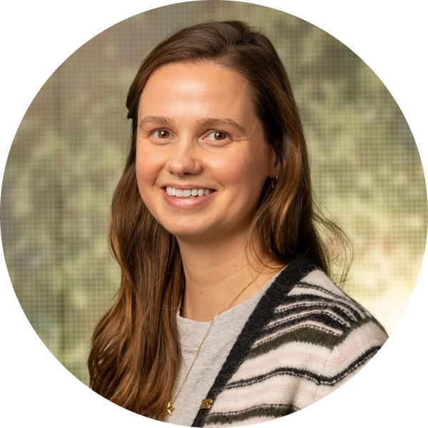

Laura Boeschoten

Lead researcher

Utrecht University

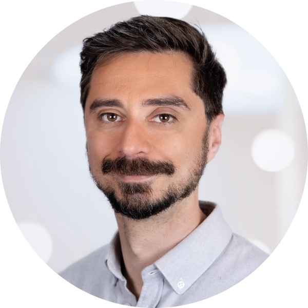

Theo Araujo

Lead researcher

University of Amsterdam

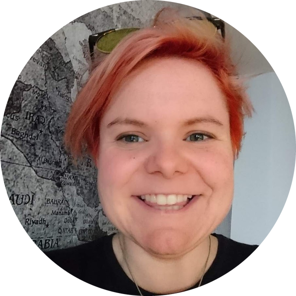

Danielle McCool

Research engineer, methodologist

Utrecht University

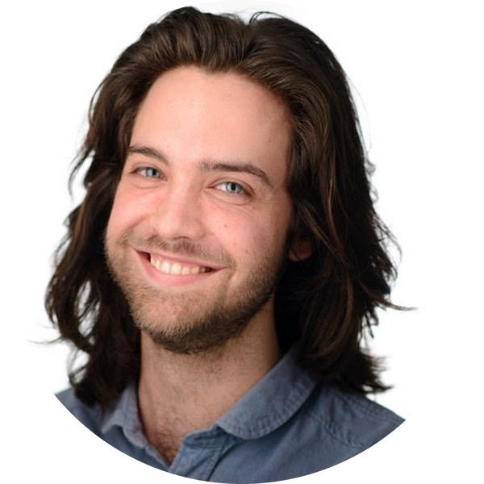

Niek de Schipper

Research engineer

Utrecht University

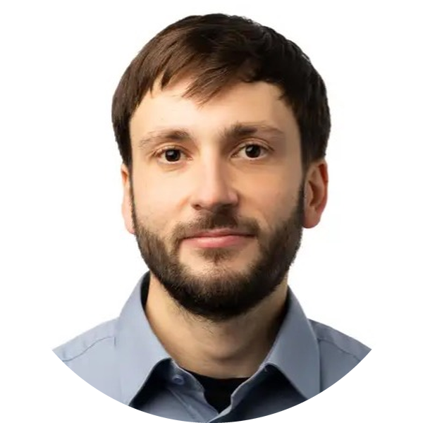

Max Paulus

Research engineer

University of Amsterdam

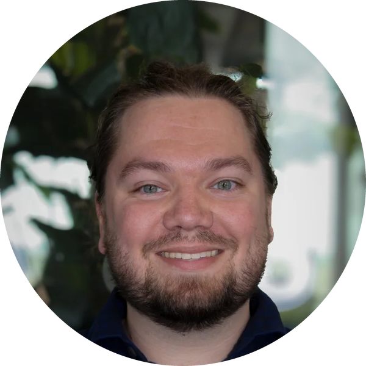

Erik van Haeringen

Research engineer

University of Amsterdam

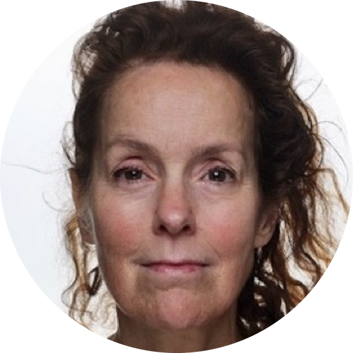

Heleen Janssen

Legal scholar

University of Amsterdam

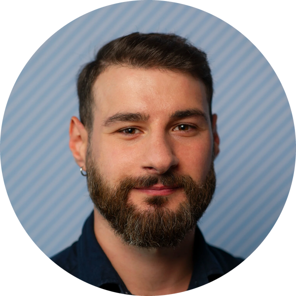

Dachi Shanidze

Community manager

University of Amsterdam

datadonation.eu/about-d3i/team

3

Stop 1 · why donation

Why donation

01

What we do on platforms leave traces that the platforms keep. GDPR's right of access provision means people can decide what to do with it.

Why donation

Your script

Your study in Next

Donate to yourself

Before you run one

datadonation.eu

4

Stop 1 · Why donation, rather than a survey

We can answer retrospective questions

Asked in a survey

Read from a donated record

Frequency

"How many videos a day did you watch last month?"

An estimated rate over a reference period.

165 a day for the median donor, IQR 19 to 370.

Every watch event, timestamped.

datadonation.eu

5

Stop 1 · Why donation, rather than a survey

We can answer retrospective questions

Asked in a survey

Read from a donated record

Frequency

"How many videos a day did you watch last month?"

An estimated rate over a reference period.

165 a day for the median donor, IQR 19 to 370.

Every watch event, timestamped.

Timing

"When did you last…?"

Dated from memory; forward and backward telescoping.

Exact timestamps across the whole window, here 180 days.

No reference period for the respondent to place.

datadonation.eu

6

Stop 1 · Why donation, rather than a survey

We can answer retrospective questions

Asked in a survey

Read from a donated record

Frequency

"How many videos a day did you watch last month?"

An estimated rate over a reference period.

165 a day for the median donor, IQR 19 to 370.

Every watch event, timestamped.

Timing

"When did you last…?"

Dated from memory; forward and backward telescoping.

Exact timestamps across the whole window, here 180 days.

No reference period for the respondent to place.

Exposure

"Did you come across content about…?"

What the respondent noticed.

The links are retrieved and the content coded.

What passed through the feed, noticed or not.

datadonation.eu

7

Stop 1 · Why donation, rather than a survey

We can answer retrospective questions

Asked in a survey

Read from a donated record

Frequency

"How many videos a day did you watch last month?"

An estimated rate over a reference period.

165 a day for the median donor, IQR 19 to 370.

Every watch event, timestamped.

Timing

"When did you last…?"

Dated from memory; forward and backward telescoping.

Exact timestamps across the whole window, here 180 days.

No reference period for the respondent to place.

Exposure

"Did you come across content about…?"

What the respondent noticed.

The links are retrieved and the content coded.

What passed through the feed, noticed or not.

Not askable

"How has the platform categorized you? Which advertisers used your data?"

No respondent can answer.

Inferred interest and advertising categories; the advertisers that used the data.

Only the record holds it.

datadonation.eu

8

Stop 1 · Why donation, what have people done?

Findings to date are both substantive and methodological

[figure not shown]

Substantive

Binge-watching is less common and less extreme than popular accounts suggest.

Observed viewing is more varied than the narrative assumes.

Van Es and Nguyen (2025), Media and Communication

[figure not shown]

Methodological

Of 2,086 LISS panel members aged 50 and over

were willing to donate

29%

started a donation

17%

completed one

12%

Completers were more often employed, highly educated, higher-income and more active.

Keusch, Struminskaya, Mulder and Jongerius (2025), JMIR

[figure not shown]

In progress

3 million

videos retrieved, transcribed and screened for crime and policing content. Collection complete; processing under way.

Van der Vegt, Utrecht University; 125 donors via Prolific, US. Preliminary.

The generative AI study (November 2026) and the supermarket study (planned for January 2027) have not yet collected data.

datadonation.eu

9

datadonation.eu

10

Stop 2 · your script

Your script and data minimization

02

Let's build a script with only what our research needs

Why donation

Your script

Your study in Next

Donate to yourself

Before you run one

Stop 2 · Your script, and Why you pick variables, rather than take everything

A download package contains far more than a study needs

The .zip the platform returns

Content

What the person made

[figure not shown]

Behavior

What the platform logged

[figure not shown]

Inference

What the platform inferred

[figure not shown]

A study may need only one or two of these classes, and only a few items within them. Asking for the whole package means receiving all the rest.

datadonation.eu

11

Exercise, part 1 · Your script, setting it up

In the script selector, pick the platform of the export you have

[datadonation.eu/software/script-selector](https://datadonation.eu/software/script-selector/)

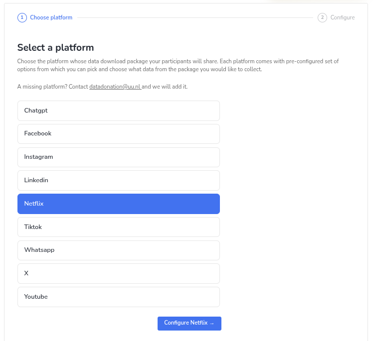

Which one?

[figure not shown]

ChatGPT

If you requested your ChatGPT export

[figure not shown]

Instagram

If you requested your Instagram export

[figure not shown]

Netflix, for everyone else

No export of your own?

Then

Configure: tick the data you want to collect, and download.

[datadonation.eu/software/script-selector](https://datadonation.eu/software/script-selector/)

12

Exercise, part 1 · Your script, setting it up

Unzip the download once. The script you made is the zip inside.

[figure not shown]

Mac

Downloads

Name

Size

build_1793625456.zip

1.6 MB

▾

build_1793625456

folder

documentation.txt

1 KB

build_vyn90tel_chatgpt_master_….zip

1.6 MB

Double-click the download. Safari often does this for you, so you may already see the folder. Do not double-click the zip inside it.

[figure not shown]

Windows

Downloads

– ☐ ✕

Name

Type

build_1793625456.zip

Compressed

build_1793625456

File folder

documentation.txt

Text

build_vyn90tel_chatgpt_master_….zip

Compressed

Open

Extract All…

Copy

Right-click the download, Extract All…, then Extract. A folder with the same name appears. Do not extract the zip inside it.

The one you need

The highlighted zip, still zipped. You upload it in part 2.

documentation.txt

The codebook: what the script extracts. Keep it for part 3.

Lost in the zips?

The inner zips for all three platforms are in the chat.

datadonation.eu/software/script-selector

13

Stop 3 · Hosting your study

Hosting your study on Next

03

Setting up your study

Why donation

Your script

Your study in Next

Donate to yourself

Before you run one

datadonation.eu

14

datadonation.eu

15

Stop 3 · hosting your study, Where your script runs, and why

Where the data are reduced determines what gets sent to the researcher

Option 1

Send everything, select later

[figure not shown]

The participant uploads the complete .zip. The researcher picks out the variables afterward and keeps everything the platform held.

Option 2

Send everything, select, delete the rest

[figure not shown]

The variables are taken out on the server and the remainder deleted. The sensitive data have still been sent, and the participant has to trust that the deletion happened.

Option 3 · Port

Select on the participant's device

[figure not shown]

The selection happens in the participant's browser before anything is sent. The participant sees what will be shared, and only that leaves the device.

Exercise, part 2 · hosting your study, on next

First, sign up for Next as a researcher

First

Open the sign-in page, pick Researcher

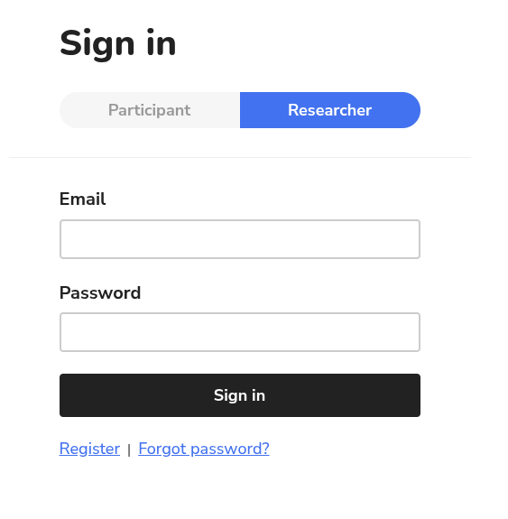

next.eyra.co/user/signin · It opens on Participant; switch to **Researcher**, then Register, bottom left.

Then

Create the account

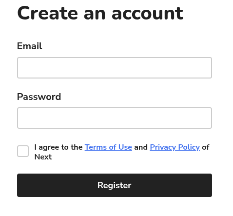

Email, password, tick the box, Register. Use an inbox you can open right now.

Finally

Confirm by email, stay signed in

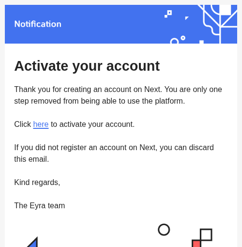

From no-reply@eyra.co: click **here** to activate, sign in, keep the window open. Nothing after a minute? Check spam.

next.eyra.co/user/signin

16

[next.eyra.co](https://next.eyra.co/)

17

Exercise, part 2 · hosting your study, customization

Customizing your study

02

Create a project

Projects, new project, pick "Data Donation", three dots menu, Rename

03

Under the Workflow tab, add Donate

The Donate task from the library contains the structure for adding the donation Flow

04

Give the Donate task your script

Data source: your platform. Flow application: the inner .zip from part 1, still zipped.

05

Set the participants' language

Participants tab. Then write “ready” in the chat; part 3 starts when most of you are.

[figure not shown]

Steps 03 and 04: the task you build on the left, the library you take it from on the right. The flow application field is where the inner .zip goes.

Couldn't unzip yours? Download a ready-made script for step 04

[figure not shown]

chatgpt.zip

[figure not shown]

instagram.zip

[figure not shown]

netflix.zip

All three at daniellemccool.github.io/releases/ · upload the file as it downloads, still zipped.

Other settings

CUSTOMIZATION

The Settings page has an About and a Consent section which you would complete in a real study. It als allows you to customize logos and banners, so participants recognize the study as coming from you.

Stop 4 · Donate to yourself

Donate to yourself

04

Preview your study and walk through it as a participant, with your own export or the Netflix sample.

Why donation

Your script

Your study in Next

Donate to yourself

Before you run one

datadonation.eu

18

Exercise, part 3 · Donate to yourself, preview the study

Click Preview in your project

01

Preview the study

Preview opens the study as a participant would see it, but doesn't set it live. It's the blue button next to the green Publish button. That one makes your study live and accessible to other people; we aren't using it today.

No working study?

1 · My live study, with all three scripts: https://next.eyra.co/a/uRCZtc?p=donate_workshop

2 · The D3I education tool: [d3i-infra.github.io/dd-education](https://d3i-infra.github.io/dd-education/)

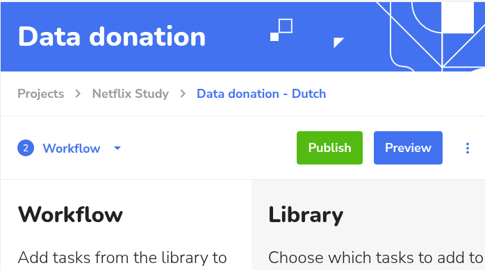

The blue Preview button, top right of the Workflow tab, in a Netflix study.

[next.eyra.co](https://next.eyra.co/)

19

Exercise, part 3 · Donate to yourself, select your DDP

Upload your export at Donate

02

Continue, then Choose file

Pick the ChatGPT or Instagram zip you requested earlier, or the Netflix sample. The script reads it inside your browser and nothing leaves your device.

No working upload?

Use the Netflix sample export: daniellemccool.github.io/test-data/netflix.zip

[figure not shown]

The study opens on its first step. Continue.

→

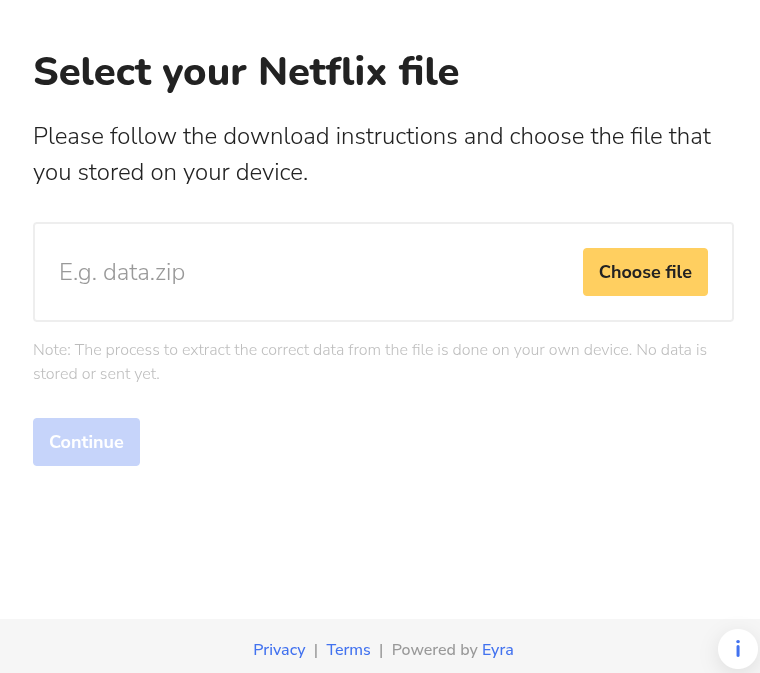

Choose file, pick your zip, Continue. Extraction runs on your device.

[next.eyra.co](https://next.eyra.co/)

20

[next.eyra.co](https://next.eyra.co/)

21

Exercise, part 3 · Donate to yourself, investigate your data

Investigate your data, see what's there

03

Look at what came out

Search the tables, delete a row or two, and see whether anything surprises you. This is exactly what a participant sees before deciding.

Before you click Yes, share

Even in a preview, that button really uploads the tables on screen to the project. Fine with the Netflix sample; with your own export, click **No** unless you want it stored in your project (or in mine, if you are using my live study).

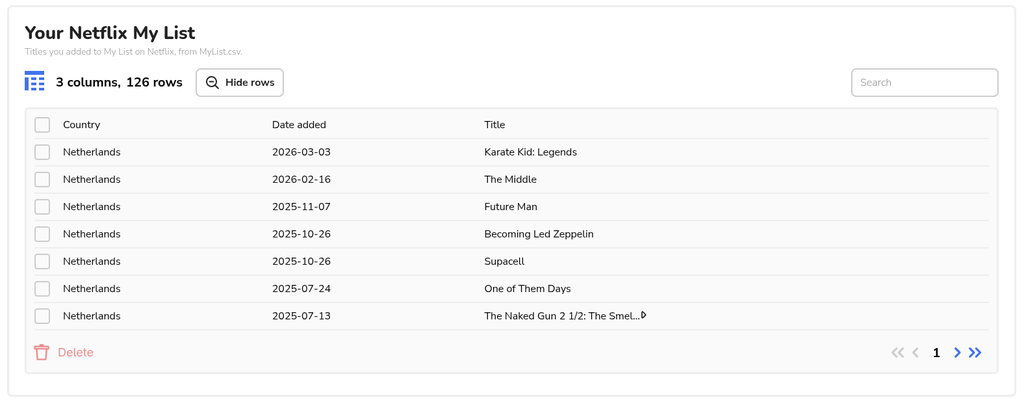

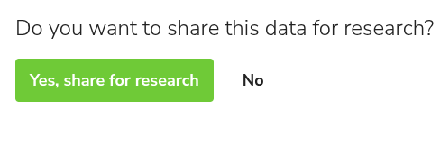

datadonation.eu

22

Exercise · Debrief

You've now experienced the whole flow

Research Setup

Platform selection, variable selection in the script selector, configuring the Next hosting

→

Participant

Data Requests, uploading the file in the browser, looking at their data, deciding on consent

→

Research Data

Would receive exactly what was on the screen after your deletions, one file per participant

01

Data minimization

The package holds everything the platform logged, but a study usually only needs a few variables. The reduction happened on your device, before anything was sent, and only what the codebook names left a participant's device.

02

Informed consent

You saw readable tables rather than a folder full of files, could remove what you wanted, and then consented to what was on the screen.

Everything you used is open source

Eyra's hosted service is just one deployment option (free for Dutch institutions). You can host the back end yourself, see [github.com/eyra/mono](https://github.com/eyra/mono/); the local-processing design is unchanged.

Stop 5 · BEFORE you run one

Before running a data donation study

05

The study you built just now is only part of the larger study. What else do you need to know?

Why donation

Your script

Your study in Next

Donate to yourself

Before you run one

datadonation.eu

23

Stop 5 · Before you run one, which parties are involved?

A study balances your needs, the participant's needs, and what data the platform makes available.

Platform realities

Platforms change their export formats without warning

17% of researchers in one survey hit a format change while a study was running. There is no obligation to tell anyone, so a script that works today may not tomorrow.

Valkenburg et al. (2024), Nature Human Behavior

Your own needs

Not every construct translates into a field in the export

Data can be missing or indirect, and everything arrives through the company's own layer of interpretation. WhatsApp exports, for instance, hold no record of reply-quoting.

Start from a real export of the platform before writing the proposal.

Legal requirements

Existing review frameworks have no box for this method

Things like the privacy statement, consent forms, and ethical applications are often designed with questionnaires in mind, especially in the social sciences, so scripts running on participant devices can pose some challenges.

D3I has templates available and can provide guidance, but ask early.

datadonation.eu

24

Stop 5 · Before you run one, what should you check?

Think about what you actually want from your study

Fill in the blanks

I would measure ______ from the export of [platform], with participants from ______, and the first thing I would need is ______.

01

Does the platform even log it?

Request your own export first. Is the construct in a field, and how far back does it go?

02

Who is on your team?

If what you want is part of the standard scripts, setup is easy. Otherwise you probably want to involve someone technical as well.

03

What is the budget for?

Participant reimbursement first; the platform is free for Dutch universities. Even *with* reimbursement, response rates can be low, around 15%.

04

Which paperwork first?

The ethics review can take a while, and some universities have DPIA requirements for hosted software. Start them after you understand the data, not before.

[datadonation.eu/prepare-a-study](https://datadonation.eu/prepare-a-study/)

25

[figure not shown]

Questions and next steps

What to take with you from today

Keep

Your Next account and project

It's a nice way to iterate quickly without a development environment. Swap today's script for the platform you want to try out for your study. If you don't see it in our [standard scripts](https://datadonation.eu/software/script-selector/), just ask and we can collaborate on something custom.

Request

Your data from the platform you would study

It can take a few days to arrive, so make your data requests early if you want to start exploring. Then visit the [Digital Footprint Explorer](https://d3i-infra.github.io/dd-education/) to check out what it contains. This will help you design a proposal.

Free to use

For Dutch universities and ODISSEI or CLARIAH members

Studies on Next run free of charge under the ODISSEI user policy. Elsewhere: Eyra's hosted service, or the open-source code at github.com/eyra/mono.

Email DataDonation@uu.nl

[datadonation.eu](https://datadonation.eu/) · [datadonation.eu/software/getting-started](https://datadonation.eu/software/getting-started/)

A service provided by ODISSEI and supported by Eyra

[figure not shown]

[figure not shown]